# Exercise: Analysis of taxi ride data

In this exercise you will use the the template notebook we went through at the lecture to make some basic computations and plots for a data set on taxi rides in New York.

## Load the libraries you need

```python
import os
import sys
import matplotlib.pyplot as plt
import seaborn as sns
import pandas as pd
import numpy as np
from matplotlib_inline.backend_inline import set_matplotlib_formats
set_matplotlib_formats('retina', 'png')
sns.set()
sns.set_style("ticks")
# scale down size of default plots
sns.set_context("paper")
import matplotlib as mpl
scale = 0.8
d = dict([(k, v*scale) for (k, v) in sns.plotting_context('paper').items()])
d['figure.figsize'] = [5.4, 3.5]
mpl.rcParams.update(d)
```

## Load the data set

Pickup and dropoff are in a fancy date-time format so we exchange them for a simpler `duration` column for the number of minutes that reach taxi ride takes.

```python
import seaborn as sns
rides = sns.load_dataset('taxis')
rides['duration'] = [x.total_seconds()/60 for x in (rides.dropoff - rides.pickup)]
rides = rides[[x for x in rides.columns if x not in ['pickup', 'dropoff']]]
rides.head()
```

|  | passengers | distance | fare | tip | tolls | total | color | payment | pickup_zone | dropoff_zone | pickup_borough | dropoff_borough | duration |
| --- | --- | --- | --- | --- | --- | --- | --- | --- | --- | --- | --- | --- | --- |
| 0 | 1 | 1.60 | 7.0 | 2.15 | 0.0 | 12.95 | yellow | credit card | Lenox Hill West | UN/Turtle Bay South | Manhattan | Manhattan | 6.250000 |
| 1 | 1 | 0.79 | 5.0 | 0.00 | 0.0 | 9.30 | yellow | cash | Upper West Side South | Upper West Side South | Manhattan | Manhattan | 7.083333 |
| 2 | 1 | 1.37 | 7.5 | 2.36 | 0.0 | 14.16 | yellow | credit card | Alphabet City | West Village | Manhattan | Manhattan | 7.400000 |
| 3 | 1 | 7.70 | 27.0 | 6.15 | 0.0 | 36.95 | yellow | credit card | Hudson Sq | Yorkville West | Manhattan | Manhattan | 25.866667 |
| 4 | 3 | 2.16 | 9.0 | 1.10 | 0.0 | 13.40 | yellow | credit card | Midtown East | Yorkville West | Manhattan | Manhattan | 9.533333 |

## Exercise 1

Get the `pickup_zones` of the five taxi rides that took the longest time:

```python
rides.sort_values(by='duration', ascending=False).head(5)
```

|  | passengers | distance | fare | tip | tolls | total | color | payment | pickup_zone | dropoff_zone | pickup_borough | dropoff_borough | duration |
| --- | --- | --- | --- | --- | --- | --- | --- | --- | --- | --- | --- | --- | --- |
| 6053 | 1 | 22.17 | 81.86 | 0.00 | 0.0 | 82.36 | green | credit card | University Heights/Morris Heights | Yorkville East | Bronx | Manhattan | 107.666667 |
| 5567 | 1 | 25.51 | 93.50 | 0.00 | 0.0 | 94.80 | green | credit card | Sunset Park West | Saint Albans | Brooklyn | Queens | 93.966667 |
| 5648 | 2 | 33.46 | 150.00 | 0.00 | 18.9 | 169.70 | green | cash | East Flushing | NaN | Queens | NaN | 89.883333 |
| 5833 | 1 | 12.79 | 57.00 | 0.00 | 0.0 | 58.80 | green | credit card | Queensbridge/Ravenswood | Flatlands | Queens | Brooklyn | 88.550000 |
| 4218 | 1 | 26.92 | 75.50 | 23.19 | 0.0 | 100.49 | yellow | credit card | JFK Airport | Cobble Hill | Queens | Brooklyn | 81.533333 |

## Exercise 2

Get the mean fare for each pickup_borough:

```python
rides.groupby('pickup_borough').fare.mean()
```

```
pickup_borough
Bronx        20.999091
Brooklyn     16.520836
Manhattan    11.152889
Queens       24.934642
Name: fare, dtype: float64
```

## Exercise 3

Are rides paid in cash shorter than those paid by credit card? (Note: Just find the mean duration for each payment type and compare them, no statistical test here, although as a bioinformatician you would probably want to do one.)

```python
rides.groupby('payment').duration.mean()
```

```
payment
cash           12.629323
credit card    15.067679
Name: duration, dtype: float64
```

## Exercise 4

In which borrough do taxis most often pick up more than one passenger? (Note: The mean is not the answer here)

```python
x=rides.groupby('pickup_borough').passengers.count()
y=rides[rides.passengers > 1].groupby('pickup_borough').passengers.count()
y/x
```

```
pickup_borough
Bronx        0.101010
Brooklyn     0.148825
Manhattan    0.272589
Queens       0.231355
Name: passengers, dtype: float64
```

## Exercise 5

Compute mean tip for all combinations of `pickup_borough` adn `dropoff_borough`. It should look like this:

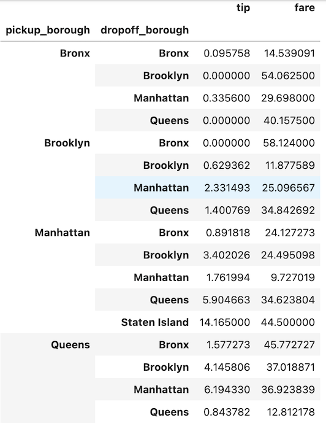

```python
df = rides[['pickup_borough','dropoff_borough','tip', 'fare']].groupby(by=['pickup_borough', 'dropoff_borough']).aggregate("mean", numeric_only=True)
df
```

| pickup_borough | dropoff_borough | tip | fare |
| --- | --- | --- | --- |
| Bronx | Bronx | 0.095758 | 14.539091 |
|  | Brooklyn | 0.000000 | 54.062500 |
|  | Manhattan | 0.335600 | 29.698000 |
|  | Queens | 0.000000 | 40.157500 |
| Brooklyn | Bronx | 0.000000 | 58.124000 |
|  | Brooklyn | 0.629362 | 11.877589 |
|  | Manhattan | 2.331493 | 25.096567 |
|  | Queens | 1.400769 | 34.842692 |
| Manhattan | Bronx | 0.891818 | 24.127273 |
|  | Brooklyn | 3.402026 | 24.495098 |
|  | Manhattan | 1.761994 | 9.727019 |
|  | Queens | 5.904663 | 34.623804 |
|  | Staten Island | 14.165000 | 44.500000 |
| Queens | Bronx | 1.577273 | 45.772727 |
|  | Brooklyn | 4.145806 | 37.018871 |
|  | Manhattan | 6.194330 | 36.923839 |
|  | Queens | 0.843782 | 12.812178 |

## Exercise 6

Add a new column, `generosity`, to the dataframe you produced in the previous exercise. It should be `tip/fare`:

```python
df['generosity'] = df.tip/df.fare
df
```

| pickup_borough | dropoff_borough | tip | fare | generosity |
| --- | --- | --- | --- | --- |
| Bronx | Bronx | 0.095758 | 14.539091 | 0.006586 |
|  | Brooklyn | 0.000000 | 54.062500 | 0.000000 |
|  | Manhattan | 0.335600 | 29.698000 | 0.011300 |
|  | Queens | 0.000000 | 40.157500 | 0.000000 |
| Brooklyn | Bronx | 0.000000 | 58.124000 | 0.000000 |
|  | Brooklyn | 0.629362 | 11.877589 | 0.052987 |
|  | Manhattan | 2.331493 | 25.096567 | 0.092901 |
|  | Queens | 1.400769 | 34.842692 | 0.040203 |
| Manhattan | Bronx | 0.891818 | 24.127273 | 0.036963 |
|  | Brooklyn | 3.402026 | 24.495098 | 0.138886 |
|  | Manhattan | 1.761994 | 9.727019 | 0.181144 |
|  | Queens | 5.904663 | 34.623804 | 0.170538 |
|  | Staten Island | 14.165000 | 44.500000 | 0.318315 |
| Queens | Bronx | 1.577273 | 45.772727 | 0.034459 |
|  | Brooklyn | 4.145806 | 37.018871 | 0.111992 |
|  | Manhattan | 6.194330 | 36.923839 | 0.167760 |
|  | Queens | 0.843782 | 12.812178 | 0.065858 |

## Exercise 7

Make a barplot (`sns.barplot`) with these parameters: `data=df, x='pickup_borough', y='generosity', hue='dropoff_borough'`. Where do generous people live?

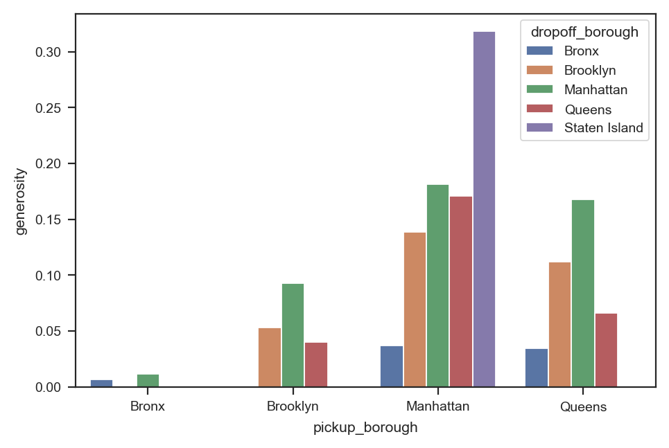

```python
sns.barplot(data=df, x='pickup_borough', y='generosity', hue='dropoff_borough')
```

## Exercise 8

Produce this plot (see the [boxplot documentation](https://seaborn.pydata.org/generated/seaborn.boxplot.html)):

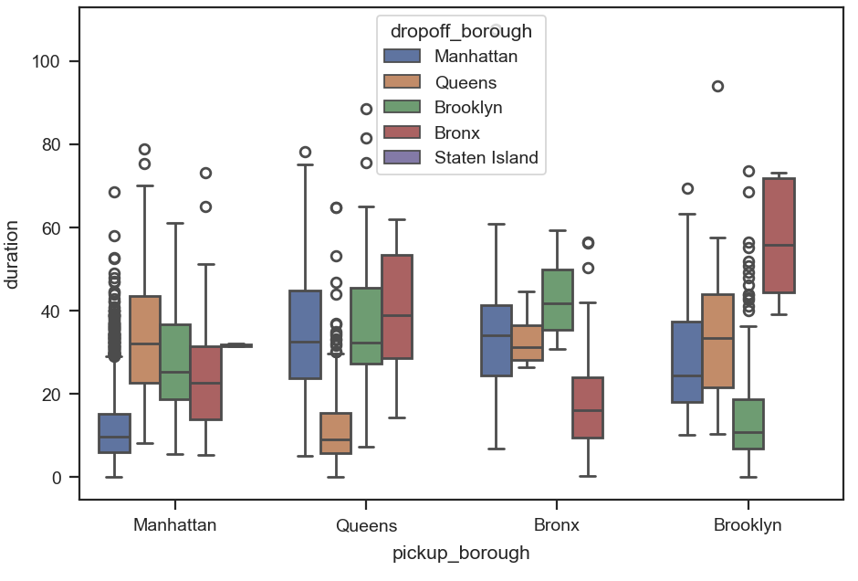

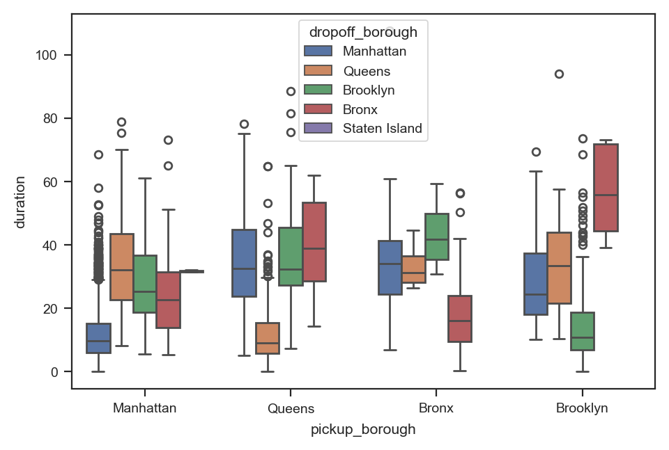

```python
sns.boxplot(data=rides, x='pickup_borough', y='duration', hue='dropoff_borough', order=None, hue_order=None, orient=None, color=None, palette=None, saturation=0.75, fill=True, dodge='auto', width=0.8, gap=0, whis=1.5, linecolor='auto', linewidth=None, fliersize=None, hue_norm=None, native_scale=False, log_scale=None, formatter=None, legend='auto', ax=None)
```

## Exercise 9

Make a histogram of the tip for fares starting on Manhattan and ending in Queens:

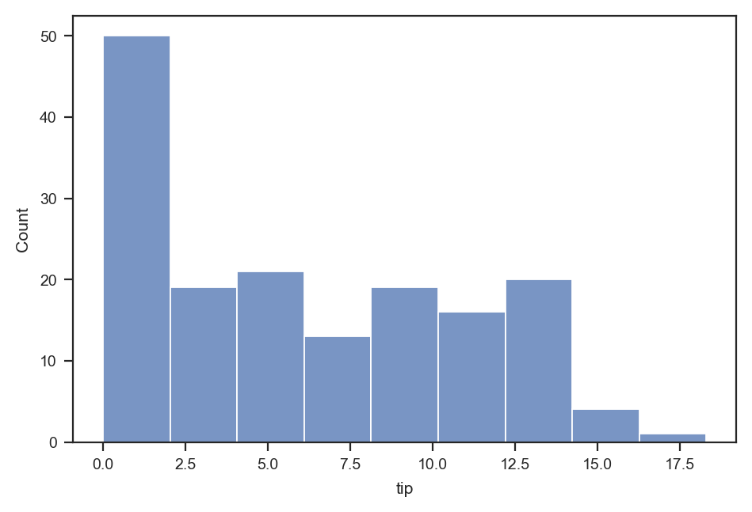

```python
df2 = rides.loc[(rides.dropoff_borough == 'Queens') & (rides.pickup_borough == 'Manhattan')]
sns.histplot(data=df2, x='tip')
```

## Exercise 10

Produce this plot, where datapoints are colored by the color of the taxi:

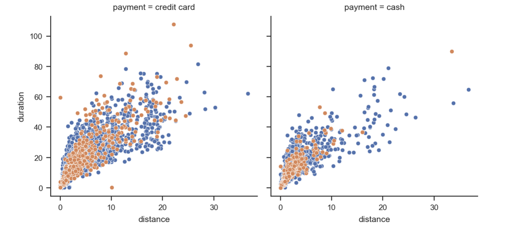

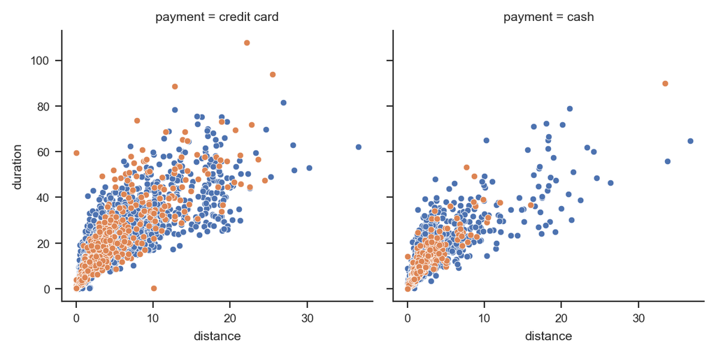

```python
g = sns.FacetGrid(data=rides, col="payment", hue='color')
g.map(sns.scatterplot, 'distance', 'duration')
```

# Exercise 11

Produce this plot where the color of the datapoints is also determined by the color of the taxi:

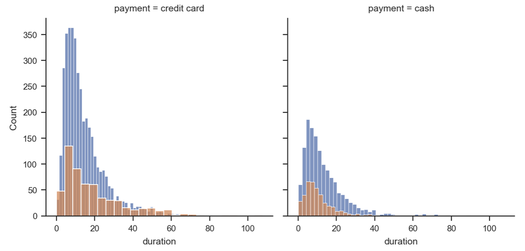

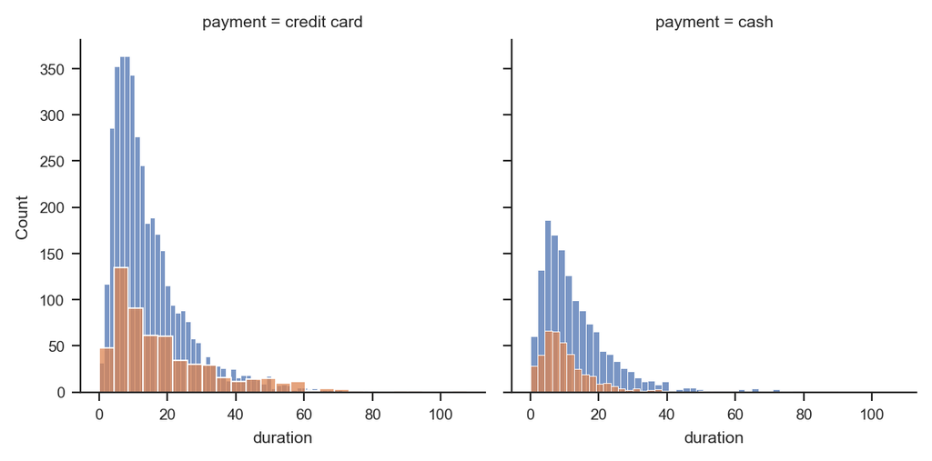

```python
g1 = sns.FacetGrid(rides, col='payment', hue='color')
g1.map(sns.histplot,'duration')
```